# Create an efficient random number generator

## Train the network

```
Testing batch size: 2
```

```
Batch size 2: 0.0338 sec/step, estimated epoch time: 646.56 min

Testing batch size: 8
```

```
Batch size 8: 0.0315 sec/step, estimated epoch time: 150.64 min

Testing batch size: 32
```

```
Batch size 32: 0.0310 sec/step, estimated epoch time: 37.12 min

Testing batch size: 64
```

```
Batch size 64: 0.0316 sec/step, estimated epoch time: 18.89 min

Testing batch size: 128
```

```
Batch size 128: 0.0327 sec/step, estimated epoch time: 9.78 min

Testing batch size: 256
```

```
Batch size 256: 0.0338 sec/step, estimated epoch time: 5.06 min

Testing batch size: 512
```

```
Batch size 512: 0.0359 sec/step, estimated epoch time: 2.68 min
```

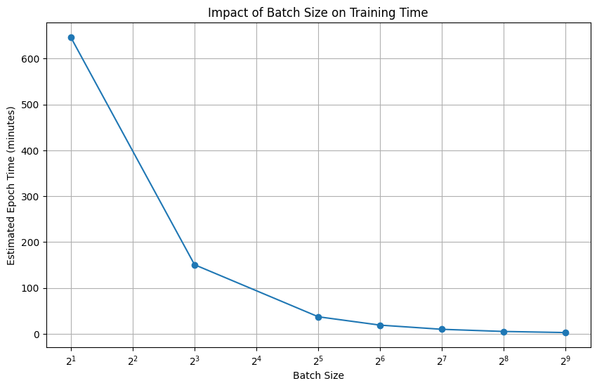

```
Batch Size Comparison Results:
----------------------------------------------------------------------
Batch Size     Time per Step (s)   Est. Epoch Time (min)
----------------------------------------------------------------------
2              0.0338s          646.56m
8              0.0315s          150.64m
32             0.0310s          37.12m
64             0.0316s          18.89m
128            0.0327s          9.78m
256            0.0338s          5.06m
512            0.0359s          2.68m
```

```python
# Convert training data to PyTorch tensors
target_ids = np.array([example[0] for example in training_data])
context_ids = np.array([example[1] for example in training_data])
labels = np.array([example[2] for example in training_data], dtype=np.float32)

# Create PyTorch dataset
train_dataset = TensorDataset(
    torch.tensor(target_ids), torch.tensor(context_ids), torch.tensor(labels)
)

# Define batch sizes to test
batch_sizes = [2, 8, 32, 64, 128, 256, 512]
timing_results = []

# Set other hyperparameters
vocab_size = len(corpus.word_to_index)
embedding_size = 100
learning_rate = 0.001

# Device configuration
device = torch.device("cuda" if torch.cuda.is_available() else "cpu")

# For each batch size, run a small portion of training to measure performance
for batch_size in batch_sizes:
    print(f"\nTesting batch size: {batch_size}")

    # Create data loader with current batch size
    train_loader = DataLoader(
        train_dataset,
        batch_size=batch_size,
        shuffle=True,
        num_workers=2,
    )

    # Initialize model and optimizer
    test_model = Word2Vec(vocab_size, embedding_size).to(device)
    test_optimizer = torch.optim.AdamW(test_model.parameters(), lr=learning_rate)
    loss_function = nn.BCEWithLogitsLoss()

    # Record start time
    start_time = time.time()

    # Run a small portion of training
    test_model.train()

    # Limit steps to avoid running too long
    max_test_steps = 100

    # Use tqdm to measure speed
    progress_bar = tqdm(train_loader, desc=f"Batch size {batch_size}")

    for step, (target_ids, context_ids, labels) in enumerate(progress_bar):
        # Move data to device
        target_ids = target_ids.to(device)
        context_ids = context_ids.to(device)
        labels = labels.to(device)

        # Forward pass
        predictions = test_model(target_ids, context_ids)

        # Calculate loss
        loss = loss_function(predictions, labels)

        # Backward pass and optimize
        test_optimizer.zero_grad()
        loss.backward()
        test_optimizer.step()

        # Stop after max_test_steps
        if step >= max_test_steps:
            break

    # Calculate timing statistics
    elapsed_time = time.time() - start_time
    steps_completed = min(max_test_steps + 1, len(train_loader))
    time_per_step = elapsed_time / steps_completed
    estimated_epoch_time = time_per_step * len(train_loader)

    timing_results.append(
        {
            "batch_size": batch_size,
            "time_per_step": time_per_step,
            "estimated_epoch_time": estimated_epoch_time,
        }
    )

    print(
        f"Batch size {batch_size}: {time_per_step:.4f} sec/step, estimated epoch time: {estimated_epoch_time / 60:.2f} min"
    )

# Plot the results
plt.figure(figsize=(10, 6))
plt.plot(
    [r["batch_size"] for r in timing_results],
    [r["estimated_epoch_time"] / 60 for r in timing_results],
    "o-",
)
plt.xscale("log", base=2)
plt.xlabel("Batch Size")
plt.ylabel("Estimated Epoch Time (minutes)")
plt.title("Impact of Batch Size on Training Time")
plt.grid(True)
plt.savefig("batch_size_timing.png")
plt.show()

# Print the results in a table format
print("\nBatch Size Comparison Results:")
print("-" * 70)
print(f"{'Batch Size':<15}{'Time per Step (s)':<20}{'Est. Epoch Time (min)':<25}")
print("-" * 70)
for result in timing_results:
    print(
        f"{result['batch_size']:<15}{result['time_per_step']:.4f}s{'':<10}{result['estimated_epoch_time'] / 60:.2f}m{'':<13}"
    )
```

#### **Batch Size Analysis Insights**

The batch size analysis reveals a compelling efficiency pattern: while per-step processing time remains relatively stable across batch sizes (0.0310s to 0.0359s), the estimated epoch training time decreases dramatically from 646 minutes with batch size 2 to just 2.68 minutes with batch size 512. This 240x speedup occurs because larger batches process more examples per forward/backward pass, reducing the total number of steps needed. The slight increase in per-step time for larger batches is negligible compared to the massive reduction in total steps, making larger batch sizes significantly more efficient for training.

```python
# FINAL MODEL TRAINING
# Convert training data to PyTorch tensors
target_ids = np.array([example[0] for example in training_data])
context_ids = np.array([example[1] for example in training_data])
labels = np.array([example[2] for example in training_data], dtype=np.float32)

# Create PyTorch dataset
train_dataset = TensorDataset(
    torch.tensor(target_ids), torch.tensor(context_ids), torch.tensor(labels)
)

# Set hyperparameters
vocab_size = len(corpus.word_to_index)
embedding_size = 100
batch_size = 512
learning_rate = 0.001
epochs = 10
max_steps = None

# Initialize weights and biases
wandb.init(
    project="word2vec",
    config={
        "embedding_size": embedding_size,
        "batch_size": batch_size,
        "learning_rate": learning_rate,
        "epochs": epochs,
        "vocab_size": vocab_size,
        "dataset": "reviews-word2vec.med.txt",
    },
)

# Create data loader
train_loader = DataLoader(
    train_dataset,
    batch_size=batch_size,
    shuffle=True,
    num_workers=2,
)

# Initialize model
model = Word2Vec(vocab_size, embedding_size)
device = torch.device("cuda" if torch.cuda.is_available() else "cpu")
model = model.to(device)

# Initialize optimizer and loss function
optimizer = torch.optim.AdamW(model.parameters(), lr=learning_rate)
loss_function = nn.BCEWithLogitsLoss()

# Training loop
print(f"Training on {device}...")
start_time = time.time()
total_steps = 0

for epoch in trange(epochs, desc="Epochs"):
    model.train()
    epoch_loss = 0
    loss_sum = 0
    log_interval = 1000  # Log to wandb every 1000 steps

    current_lr = learning_rate * (1.0 - epoch / epochs)
    for param_group in optimizer.param_groups:
        param_group["lr"] = current_lr

    # Use tqdm for the inner loop too
    progress_bar = tqdm(train_loader, desc=f"Epoch {epoch + 1}/{epochs}")

    for step, (target_ids, context_ids, labels) in enumerate(progress_bar):
        # Move data to device
        target_ids = target_ids.to(device)
        context_ids = context_ids.to(device)
        labels = labels.to(device)

        # Forward pass
        predictions = model(target_ids, context_ids)

        # Calculate loss
        loss = loss_function(predictions, labels)

        # Backward pass and optimize
        optimizer.zero_grad()
        loss.backward()

        if step % 500 == 0:  # Print every 500 batches
            # Check if gradients are flowing
            target_grad_norm = (
                model.target_embeddings.weight.grad.norm().item()
                if model.target_embeddings.weight.grad is not None
                else 0
            )
            context_grad_norm = (
                model.context_embeddings.weight.grad.norm().item()
                if model.context_embeddings.weight.grad is not None
                else 0
            )

            print(
                f"Batch {step}, Loss: {loss.item():.6f}, Target grad norm: {target_grad_norm:.6f}, Context grad norm: {context_grad_norm:.6f}"
            )
        optimizer.step()

        # Update loss statistics
        loss_value = loss.item()
        epoch_loss += loss_value
        loss_sum += loss_value

        # Update progress bar
        progress_bar.set_postfix({"Loss": f"{epoch_loss / (step + 1):.4f}"})

        # Log to wandb periodically
        if (step + 1) % log_interval == 0:
            avg_loss = loss_sum / log_interval
            wandb.log({"loss": avg_loss, "step": total_steps})
            loss_sum = 0

        total_steps += 1

        # Early stopping if needed
        if max_steps is not None and total_steps >= max_steps:
            print(f"Reached max steps ({max_steps}). Stopping early.")
            break

    # Log epoch statistics
    epoch_avg_loss = epoch_loss / len(train_loader)
    wandb.log({"epoch": epoch, "epoch_loss": epoch_avg_loss})
    print(f"Epoch {epoch + 1}/{epochs} - Avg Loss: {epoch_avg_loss:.4f}")

# Training complete
training_time = time.time() - start_time
print(f"Training completed in {training_time:.2f} seconds")

# Set model to evaluation mode
model.eval()
```

```
wandb: Using wandb-core as the SDK backend.  Please refer to https://wandb.me/wandb-core for more information.
wandb: Currently logged in as: axbhatta (axbhatta-university-of-michigan) to https://api.wandb.ai. Use `wandb login --relogin` to force relogin
```

Tracking run with wandb version 0.19.7

Run data is saved locally in `/Users/anupamabhatta/Desktop/u-m/SI 630/Homework 2/wandb/run-20250227_024537-t0e949ma`

Syncing run **[lively-blaze-17](https://wandb.ai/axbhatta-university-of-michigan/word2vec/runs/t0e949ma)** to [Weights & Biases](https://wandb.ai/axbhatta-university-of-michigan/word2vec) ([docs](https://wandb.me/developer-guide))

View project at https://wandb.ai/axbhatta-university-of-michigan/word2vec

View run at https://wandb.ai/axbhatta-university-of-michigan/word2vec/runs/t0e949ma

```
Training on cpu...
```

```
Batch 0, Loss: 0.806100, Target grad norm: 0.045808, Context grad norm: 0.044719
```

```
Batch 500, Loss: 0.657150, Target grad norm: 0.036550, Context grad norm: 0.034284
```

```
Batch 1000, Loss: 0.633538, Target grad norm: 0.031476, Context grad norm: 0.030399
```

```
Batch 1500, Loss: 0.614698, Target grad norm: 0.027889, Context grad norm: 0.027375
```

```
Batch 2000, Loss: 0.607158, Target grad norm: 0.025920, Context grad norm: 0.025954
```

```
Batch 2500, Loss: 0.598566, Target grad norm: 0.024485, Context grad norm: 0.025146
```

```
Batch 3000, Loss: 0.601138, Target grad norm: 0.024311, Context grad norm: 0.024972
```

```
Batch 3500, Loss: 0.591795, Target grad norm: 0.024667, Context grad norm: 0.024183
```

```
Batch 4000, Loss: 0.596943, Target grad norm: 0.025347, Context grad norm: 0.024362
```

```
Batch 0, Loss: 0.564135, Target grad norm: 0.022487, Context grad norm: 0.021918
```

```
Batch 500, Loss: 0.563666, Target grad norm: 0.023859, Context grad norm: 0.023707
```

```
Batch 1000, Loss: 0.562797, Target grad norm: 0.024762, Context grad norm: 0.024357
```

```
Batch 1500, Loss: 0.574562, Target grad norm: 0.025905, Context grad norm: 0.025682
```

```
Batch 2000, Loss: 0.578679, Target grad norm: 0.026221, Context grad norm: 0.025446
```

```
Batch 2500, Loss: 0.575514, Target grad norm: 0.026607, Context grad norm: 0.025514
```

```
Batch 3000, Loss: 0.573583, Target grad norm: 0.026633, Context grad norm: 0.026230
```

```
Batch 3500, Loss: 0.572819, Target grad norm: 0.026979, Context grad norm: 0.026008
```

```
Batch 4000, Loss: 0.568945, Target grad norm: 0.026786, Context grad norm: 0.026185
```

```
Batch 0, Loss: 0.537105, Target grad norm: 0.024701, Context grad norm: 0.024413
```

```
Batch 500, Loss: 0.549955, Target grad norm: 0.026775, Context grad norm: 0.025738
```

```
Batch 1000, Loss: 0.548505, Target grad norm: 0.027436, Context grad norm: 0.026841
```

```
Batch 1500, Loss: 0.550575, Target grad norm: 0.028396, Context grad norm: 0.027289
```

```
Batch 2000, Loss: 0.551425, Target grad norm: 0.028222, Context grad norm: 0.027359
```

```
Batch 2500, Loss: 0.554157, Target grad norm: 0.028609, Context grad norm: 0.027825
```

```
Batch 3000, Loss: 0.549442, Target grad norm: 0.028656, Context grad norm: 0.028339
```

```
Batch 3500, Loss: 0.556363, Target grad norm: 0.029389, Context grad norm: 0.028114
```

```
Batch 4000, Loss: 0.551610, Target grad norm: 0.028808, Context grad norm: 0.027966
```

```
Batch 0, Loss: 0.523753, Target grad norm: 0.027083, Context grad norm: 0.026859
```

```
Batch 500, Loss: 0.523643, Target grad norm: 0.028361, Context grad norm: 0.027769
```

```
Batch 1000, Loss: 0.525226, Target grad norm: 0.028362, Context grad norm: 0.028642
```

```
Batch 1500, Loss: 0.538240, Target grad norm: 0.029615, Context grad norm: 0.029055
```

```
Batch 2000, Loss: 0.538056, Target grad norm: 0.029982, Context grad norm: 0.029520
```

```
Batch 2500, Loss: 0.541295, Target grad norm: 0.030158, Context grad norm: 0.029754
```

```
Batch 3000, Loss: 0.540366, Target grad norm: 0.030063, Context grad norm: 0.030123
```

```
Batch 3500, Loss: 0.542546, Target grad norm: 0.030103, Context grad norm: 0.030028
```

```
Batch 4000, Loss: 0.549563, Target grad norm: 0.030741, Context grad norm: 0.030034
```

```
Batch 0, Loss: 0.514981, Target grad norm: 0.028887, Context grad norm: 0.027841
```

```
Batch 500, Loss: 0.521701, Target grad norm: 0.029357, Context grad norm: 0.029056
```

```
Batch 1000, Loss: 0.520771, Target grad norm: 0.029841, Context grad norm: 0.029635
```

```
Batch 1500, Loss: 0.524092, Target grad norm: 0.030718, Context grad norm: 0.030315
```

```
Batch 2000, Loss: 0.527243, Target grad norm: 0.030505, Context grad norm: 0.030505
```

```
Batch 2500, Loss: 0.529443, Target grad norm: 0.030582, Context grad norm: 0.029482
```

```
Batch 3000, Loss: 0.530588, Target grad norm: 0.030637, Context grad norm: 0.030894
```

```
Batch 3500, Loss: 0.538615, Target grad norm: 0.031115, Context grad norm: 0.030978
```

```
Batch 4000, Loss: 0.540520, Target grad norm: 0.031006, Context grad norm: 0.030372
```

```
Batch 0, Loss: 0.517961, Target grad norm: 0.029293, Context grad norm: 0.029119
```

```
Batch 500, Loss: 0.511032, Target grad norm: 0.029653, Context grad norm: 0.030090
```

```
Batch 1000, Loss: 0.514696, Target grad norm: 0.030567, Context grad norm: 0.030443
```

```
Batch 1500, Loss: 0.520442, Target grad norm: 0.031038, Context grad norm: 0.030419
```

```
Batch 2000, Loss: 0.521458, Target grad norm: 0.030684, Context grad norm: 0.030874
```

```
Batch 2500, Loss: 0.517272, Target grad norm: 0.031274, Context grad norm: 0.031100
```

```
Batch 3000, Loss: 0.523599, Target grad norm: 0.031727, Context grad norm: 0.030806
```

```
Batch 3500, Loss: 0.525856, Target grad norm: 0.031535, Context grad norm: 0.031388
```

```
Batch 4000, Loss: 0.528439, Target grad norm: 0.031557, Context grad norm: 0.030635
```

```
Batch 0, Loss: 0.512125, Target grad norm: 0.030065, Context grad norm: 0.029759
```

```
Batch 500, Loss: 0.507729, Target grad norm: 0.030759, Context grad norm: 0.030706
```

```
Batch 1000, Loss: 0.508828, Target grad norm: 0.030545, Context grad norm: 0.030903
```

```
Batch 1500, Loss: 0.508096, Target grad norm: 0.030686, Context grad norm: 0.031365
```

```
Batch 2000, Loss: 0.509534, Target grad norm: 0.031258, Context grad norm: 0.031317
```

```
Batch 2500, Loss: 0.511368, Target grad norm: 0.031297, Context grad norm: 0.031342
```

```
Batch 3000, Loss: 0.515064, Target grad norm: 0.031369, Context grad norm: 0.031553
```

```
Batch 3500, Loss: 0.514281, Target grad norm: 0.031801, Context grad norm: 0.030731
```

```
Batch 4000, Loss: 0.509694, Target grad norm: 0.031046, Context grad norm: 0.031631
```

```
Batch 0, Loss: 0.504315, Target grad norm: 0.030365, Context grad norm: 0.030019
```

```
Batch 500, Loss: 0.510433, Target grad norm: 0.030647, Context grad norm: 0.030399
```

```
Batch 1000, Loss: 0.502645, Target grad norm: 0.031056, Context grad norm: 0.031456
```

```
Batch 1500, Loss: 0.506966, Target grad norm: 0.031022, Context grad norm: 0.030838
```

```
Batch 2000, Loss: 0.503645, Target grad norm: 0.030890, Context grad norm: 0.031526
```

```
Batch 2500, Loss: 0.507650, Target grad norm: 0.032104, Context grad norm: 0.032314
```

```
Batch 3000, Loss: 0.510807, Target grad norm: 0.031505, Context grad norm: 0.031579
```

```
Batch 3500, Loss: 0.510263, Target grad norm: 0.031427, Context grad norm: 0.032385
```

```
Batch 4000, Loss: 0.514832, Target grad norm: 0.031497, Context grad norm: 0.032509
```

```
Batch 0, Loss: 0.505429, Target grad norm: 0.030919, Context grad norm: 0.030921
```

```
Batch 500, Loss: 0.506195, Target grad norm: 0.030931, Context grad norm: 0.031227
```

```
Batch 1000, Loss: 0.509269, Target grad norm: 0.031542, Context grad norm: 0.031078
```

```
Batch 1500, Loss: 0.506565, Target grad norm: 0.031739, Context grad norm: 0.030955
```

```
Batch 2000, Loss: 0.509413, Target grad norm: 0.031464, Context grad norm: 0.031856
```

```
Batch 2500, Loss: 0.506214, Target grad norm: 0.031821, Context grad norm: 0.030892
```

```
Batch 3000, Loss: 0.514459, Target grad norm: 0.032519, Context grad norm: 0.031765
```

```
Batch 3500, Loss: 0.510131, Target grad norm: 0.031574, Context grad norm: 0.031589
```

```
Batch 4000, Loss: 0.516147, Target grad norm: 0.031840, Context grad norm: 0.031842
```

```
Batch 0, Loss: 0.494660, Target grad norm: 0.030854, Context grad norm: 0.031006
```

```
Batch 500, Loss: 0.502446, Target grad norm: 0.030726, Context grad norm: 0.031561
```

```
Batch 1000, Loss: 0.494833, Target grad norm: 0.030619, Context grad norm: 0.031755
```

```
Batch 1500, Loss: 0.501477, Target grad norm: 0.030574, Context grad norm: 0.031982
```

```
Batch 2000, Loss: 0.504244, Target grad norm: 0.031359, Context grad norm: 0.031603
```

```
Batch 2500, Loss: 0.505813, Target grad norm: 0.031415, Context grad norm: 0.032006
```

```
Batch 3000, Loss: 0.512073, Target grad norm: 0.031947, Context grad norm: 0.031274
```

```
Batch 3500, Loss: 0.506182, Target grad norm: 0.031396, Context grad norm: 0.032397
```

```
Batch 4000, Loss: 0.505057, Target grad norm: 0.031869, Context grad norm: 0.032261
```

```
Training completed in 1196.44 seconds
```

```
Word2Vec(
  (target_embeddings): Embedding(52081, 100)
  (context_embeddings): Embedding(52081, 100)
)
```